# Sales Data - Case Study Answers

BaselRBootcam April 2018

### Overview

In this case study, we will look at sales data from a retailer. There are two datasets, one called “sales.csv”, and one called “stores.csv”. You will first perform some data wrangling and merge the two datasets and then save the merged dataset as “retailer_sales.csv”. Below you find two tables with the variable names and a short description of each variable of the two datasets. After that you will have the oportunity to “pick your adventure” and do the analysis you like. For example, you could check how large the fluctuations of sales are per store, or whether sales numbers go up or down in holidays, how well you can predict sales numbers from the other variables, e.g. using a regression, or you could run a time series analysis to predict future turnovers. For each of these suggestions you will find a short paragraph that provides some guidance and hints to what you could do, but feel free to play with the dataset as you wish. Because there are multiple timepoints per store involved, we will often have to either aggregate the data over these, or will not be able to interpret p-values. One method to address this issue is by using mixed effects models. This is rather advanced and we will not cover it here. However, if you are familiar with the method and want to give it a try in R, you can use the `lmer` function from the `lme4` package.

Table1. “sales.csv” variable description:

| Variable | Description |
| --- | --- |
| Store | Numeric Id of each of the stores |
| DayOfWeek | A number representing the day of the week |
| Date | The date |
| Sales | The turnover on a given day |
| Customers | The number of costumers on a given day |
| Open | Whether the store was open (1) or closed (0) on a given day |
| Promo | Whether a store was running a promo that day |
| StateHoliday | Whether there where (NA) or were no (0) state holidays that day. |
| SchoolHoliday | If the store on a given date was affected by the closure of public schools (1) or not (0) |

Table 2. “stores.csv” variable description:

[output not shown]

### Data I

1. Open a new R script and save it as a new file called `sales_case_study.R`. At the top of the script, using comments, write your name and the date. Then, load the `tidyverse`package. Here’s how the top of your script should look:

```r
## NAME
## DATE
## Sales Data - Case Study

library(tidyverse)
```

2. Load in the “sales.csv”, and “stores.csv” datasets from your data folder.

```r
# Load data from your local data file of your R project

sales <- read_csv("data/sales.csv")
stores <- read_csv("data/stores.csv")
```

3. Get a first impression of the datasets by looking at a few rows of them.

```r
# Get to know the data
head(sales)
```

```
# A tibble: 6 x 9
  Store DayOfWeek Date       Sales Customers  Open Promo StateHo… SchoolH…
  <int>     <int> <date>     <int>     <int> <int> <int>    <int>    <int>
1     1         5 2015-07-31  5263       555     1     1        0        1
2     2         5 2015-07-31  6064       625     1     1        0        1
3     3         5 2015-07-31  8314       821     1     1        0        1
4     4         5 2015-07-31 13995      1498     1     1        0        1
5     5         5 2015-07-31  4822       559     1     1        0        1
6     6         5 2015-07-31  5651       589     1     1        0        1
```

```r
str(sales)
```

```
Classes 'tbl_df', 'tbl' and 'data.frame':   1017209 obs. of  9 variables:
 $ Store        : int  1 2 3 4 5 6 7 8 9 10 ...
 $ DayOfWeek    : int  5 5 5 5 5 5 5 5 5 5 ...
 $ Date         : Date, format: "2015-07-31" "2015-07-31" ...
 $ Sales        : int  5263 6064 8314 13995 4822 5651 15344 8492 8565 7185 ...
 $ Customers    : int  555 625 821 1498 559 589 1414 833 687 681 ...
 $ Open         : int  1 1 1 1 1 1 1 1 1 1 ...
 $ Promo        : int  1 1 1 1 1 1 1 1 1 1 ...
 $ StateHoliday : int  0 0 0 0 0 0 0 0 0 0 ...
 $ SchoolHoliday: int  1 1 1 1 1 1 1 1 1 1 ...
 - attr(*, "problems")=Classes 'tbl_df', 'tbl' and 'data.frame':    31050 obs. of  5 variables:
  ..$ row     : int  63556 63558 63560 63561 63564 63568 63569 63571 63574 63575 ...
  ..$ col     : chr  "StateHoliday" "StateHoliday" "StateHoliday" "StateHoliday" ...
  ..$ expected: chr  "an integer" "an integer" "an integer" "an integer" ...
  ..$ actual  : chr  "a" "a" "a" "a" ...
  ..$ file    : chr  "'https://raw.githubusercontent.com/therbootcamp/therbootcamp.github.io/master/_sessions/_data/sales.csv'" "'https://raw.githubusercontent.com/therbootcamp/therbootcamp.github.io/master/_sessions/_data/sales.csv'" "'https://raw.githubusercontent.com/therbootcamp/therbootcamp.git…
 - attr(*, "spec")=List of 2
  ..$ cols   :List of 9
  .. ..$ Store        : list()
  .. .. ..- attr(*, "class")= chr  "collector_integer" "collector"
  .. ..$ DayOfWeek    : list()
  .. .. ..- attr(*, "class")= chr  "collector_integer" "collector"
  .. ..$ Date         :List of 1
  .. .. ..$ format: chr ""
  .. .. ..- attr(*, "class")= chr  "collector_date" "collector"
  .. ..$ Sales        : list()
  .. .. ..- attr(*, "class")= chr  "collector_integer" "collector"
  .. ..$ Customers    : list()
  .. .. ..- attr(*, "class")= chr  "collector_integer" "collector"
  .. ..$ Open         : list()
  .. .. ..- attr(*, "class")= chr  "collector_integer" "collector"
  .. ..$ Promo        : list()
  .. .. ..- attr(*, "class")= chr  "collector_integer" "collector"
  .. ..$ StateHoliday : list()
  .. .. ..- attr(*, "class")= chr  "collector_integer" "collector"
  .. ..$ SchoolHoliday: list()
  .. .. ..- attr(*, "class")= chr  "collector_integer" "collector"
  ..$ default: list()
  .. ..- attr(*, "class")= chr  "collector_guess" "collector"
  ..- attr(*, "class")= chr "col_spec"
```

```r
head(stores)
```

```
# A tibble: 6 x 10
  Store StoreType Assortment Compe… Compe… Compe… Promo2 Prom… Prom… Prom…
  <int> <chr>     <chr>       <int>  <int>  <int>  <int> <int> <int> <chr>
1     1 c         a            1270      9   2008      0    NA    NA <NA>
2     2 a         a             570     11   2007      1    13  2010 Jan,…
3     3 a         a           14130     12   2006      1    14  2011 Jan,…
4     4 c         c             620      9   2009      0    NA    NA <NA>
5     5 a         a           29910      4   2015      0    NA    NA <NA>
6     6 a         a             310     12   2013      0    NA    NA <NA>
```

```r
str(stores)
```

```
Classes 'tbl_df', 'tbl' and 'data.frame':   1115 obs. of  10 variables:
 $ Store                    : int  1 2 3 4 5 6 7 8 9 10 ...
 $ StoreType                : chr  "c" "a" "a" "c" ...
 $ Assortment               : chr  "a" "a" "a" "c" ...
 $ CompetitionDistance      : int  1270 570 14130 620 29910 310 24000 7520 2030 3160 ...
 $ CompetitionOpenSinceMonth: int  9 11 12 9 4 12 4 10 8 9 ...
 $ CompetitionOpenSinceYear : int  2008 2007 2006 2009 2015 2013 2013 2014 2000 2009 ...
 $ Promo2                   : int  0 1 1 0 0 0 0 0 0 0 ...
 $ Promo2SinceWeek          : int  NA 13 14 NA NA NA NA NA NA NA ...
 $ Promo2SinceYear          : int  NA 2010 2011 NA NA NA NA NA NA NA ...
 $ PromoInterval            : chr  NA "Jan,Apr,Jul,Oct" "Jan,Apr,Jul,Oct" NA ...
 - attr(*, "spec")=List of 2
  ..$ cols   :List of 10
  .. ..$ Store                    : list()
  .. .. ..- attr(*, "class")= chr  "collector_integer" "collector"
  .. ..$ StoreType                : list()
  .. .. ..- attr(*, "class")= chr  "collector_character" "collector"
  .. ..$ Assortment               : list()
  .. .. ..- attr(*, "class")= chr  "collector_character" "collector"
  .. ..$ CompetitionDistance      : list()
  .. .. ..- attr(*, "class")= chr  "collector_integer" "collector"
  .. ..$ CompetitionOpenSinceMonth: list()
  .. .. ..- attr(*, "class")= chr  "collector_integer" "collector"
  .. ..$ CompetitionOpenSinceYear : list()
  .. .. ..- attr(*, "class")= chr  "collector_integer" "collector"
  .. ..$ Promo2                   : list()
  .. .. ..- attr(*, "class")= chr  "collector_integer" "collector"
  .. ..$ Promo2SinceWeek          : list()
  .. .. ..- attr(*, "class")= chr  "collector_integer" "collector"
  .. ..$ Promo2SinceYear          : list()
  .. .. ..- attr(*, "class")= chr  "collector_integer" "collector"
  .. ..$ PromoInterval            : list()
  .. .. ..- attr(*, "class")= chr  "collector_character" "collector"
  ..$ default: list()
  .. ..- attr(*, "class")= chr  "collector_guess" "collector"
  ..- attr(*, "class")= chr "col_spec"
```

### Data Wrangling

4. From the stores data, only select the following variables: Store, Assortment, CompetitionDistance, CompetitionOpenSinceYear, Promo2. The variable Assortment contains the values “a”, “b”, and “c”. This is not very helpful. Change them so that “a” is now “basic”, “b” is now “extra”, and “c” is now “extended”.

```r
stores <- stores %>%
  select(Store, Assortment, CompetitionDistance, CompetitionOpenSinceYear, Promo2) %>%
  mutate(Assortment = case_when(Assortment == "a" ~ "basic",
                                Assortment == "b" ~ "extra",
                                Assortment == "c" ~ "extended"))
```

5. Join the stores data with the sales data (check out the `left_join()` function for this).

```r
sales <- left_join(sales, stores, by = "Store")
```

6. The sales data contains an error in the state_holiday variable. There are `NA`s where there should be `1`s. Change this (remember that `variable == NA` won’t yield the result you want; use `is.na(variable)` instead).

```r
sales <- sales %>%
    mutate(StateHoliday = case_when(is.na(StateHoliday) ~ 1,
                                   TRUE ~ 0))
```

7. Rename the variables to be lower case and with underscores between words. Afterwards your variables should be named like this: “store”, “week_day”, “date”, “sales”, “customers”, “open”, “promo”, “state_holiday”, “school_holiday”, “assortment”, “competition_distance”, “competition_open_since”, and “store_promo”.

```r
names(sales) <- c("store", "week_day", "date", "sales", "customers", "open",
                  "promo", "state_holiday", "school_holiday", "assortment",
                  "competition_distance", "competition_open_since","store_promo")
```

### Data O

8. Save the prepared data as “retailer_sales.csv” (this is easy to do with the `write_csv()` function).

```r
write_csv(sales, "retailer_sales.csv")
```

### Statistics

#### Flucutations over Days

To look at the average fluctuations over days you, we suggest you take a subsample of a few stores. You could then plot the individual trajectories, and if you like also add a mean line. You can also use a repeated measures test, to have a statistical test of the stability (you could, for example, use a correlation between two timepoints, or aggregate sales data of stores for each timepoint and run a regression. Note that with these two methods you will violate the assumption of independence of the data, so you cannot interpret the p-value).

9. Run the following code to get a visual impression of how large the fluctuations are.

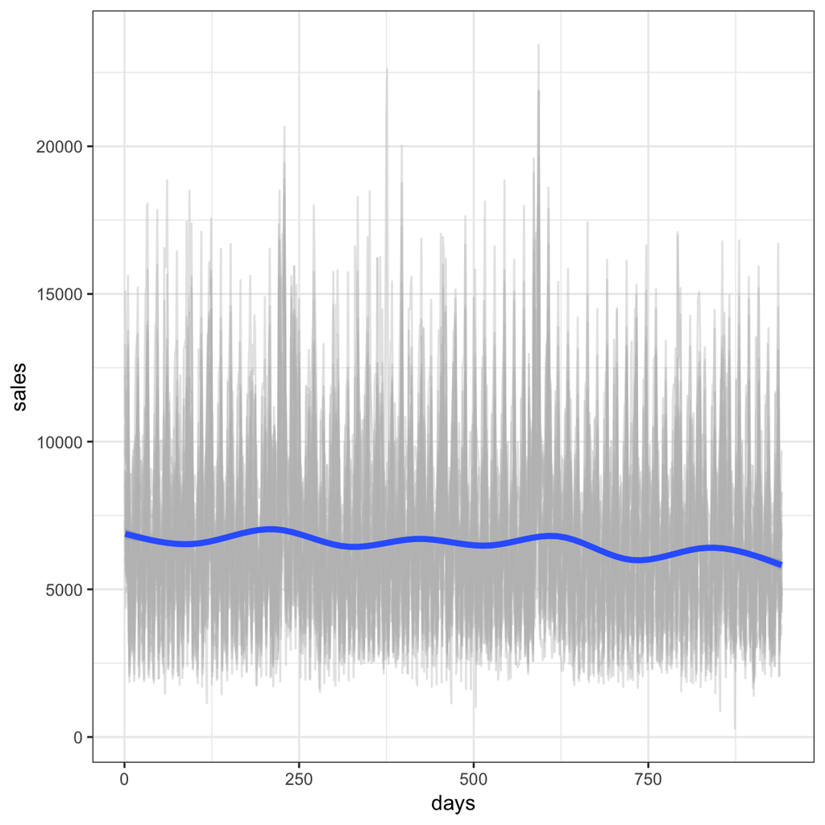

```r
# first create a variable called "days" that is a counter
# for the number of days and will be easier to use than
# the date variable
store_ids <- unique(sales$store)
sales$days <- 0

for (i in store_ids){
  sales$days[sales$store == i] <- seq_len(sum(sales$store == i))
}

# take a subsample to plot
sales_sub <- sales[sales$store %in% sample(1:1115, 30),]

# get rid of dates where the stores were closed
sales_sub <- filter(sales_sub, sales > 0)


### Create a plot using ggplot:

ggplot(sales_sub, aes(x = days, y = sales)) + # specify the data
  geom_line(aes(group = store), col = "grey", alpha = .4) + # add line per store
  stat_smooth(lwd = 1.5) +  # add an average line
  theme_bw()                # theme for white plotting window
```

10. Randomly sample two timepoints (use the `sample()` function for this) from the `days` variable created above, and run a correlation.

```r
# correlation between two of the timepoints
r_ds <- sample(sales$days, 2)

cor(sales$sales[sales$days == r_ds[1]], sales$sales[sales$days == r_ds[2]])
```

```
[1] 0.9030174
```

11. Summarise the sales data over `days` (i.e. for each day, take the mean), and store this as an object called `sales_agg`. Then run a regression (the function to run a regression is `lm()`).

```r
# regression

# first summarise the data
sales_agg <- sales %>%
  group_by(days) %>%
  summarise(
    sales = mean(sales)
  )

# then run regression
mod <- lm(sales ~ days, data = sales_agg)

summary(mod)
```

```
Call:
lm(formula = sales ~ days, data = sales_agg)

Residuals:
    Min      1Q  Median      3Q     Max
-5785.7  -511.7   293.5  1514.4  7247.4

Coefficients:
             Estimate Std. Error t value Pr(>|t|)
(Intercept) 6012.6989   170.5927   35.25   <2e-16 ***
days          -0.5203     0.3134   -1.66   0.0972 .
---
Signif. codes:  0 '***' 0.001 '**' 0.01 '*' 0.05 '.' 0.1 ' ' 1

Residual standard error: 2616 on 940 degrees of freedom
Multiple R-squared:  0.002923,  Adjusted R-squared:  0.001862
F-statistic: 2.756 on 1 and 940 DF,  p-value: 0.09725
```

12. Compute the coefficient of variation, i.e. the standard deviation scaled on the mean (use the `sd()` function and divide by the `mean()`), of each stores turnovers (`sales` variable). You can do this by using `dplyr`’s `summarise()` function. Store this as an object called `sales_cv`, with the variable `cv`. Only use days on which the stores were open to not introduce extra noise (use `filter()` for this).

```r
# regression

# first summarise the data
sales_cv <- sales %>%
  filter(open != 0) %>%
  group_by(store) %>%
  summarise(
    cv = sd(sales) / mean(sales)
  )
```

13. Plot the distribution of the coefficient of variation using the following code:

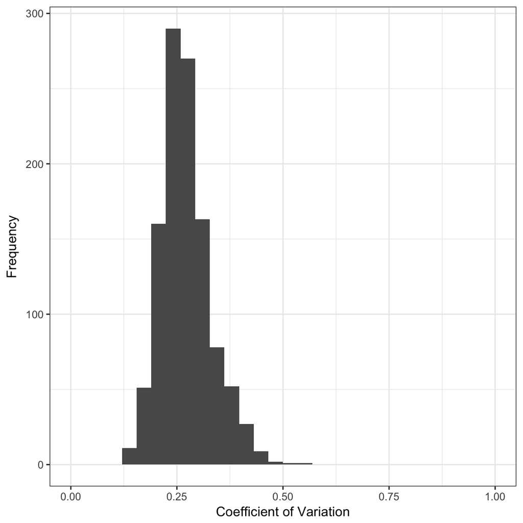

```r
ggplot(sales_cv, aes(cv)) +  # the data to plot
  geom_histogram() +         # function to create a histogram
  xlim(c(0, 1)) +            # range of the x-axis
  xlab("Coefficient of Variation") + # x-axis title
  ylab("Frequency") +        # y-axis title
  theme_bw()                 # white theme (white plotting window)
```

#### Sales numbers in holidays

14. To test the effects of state holidays, filter the dataset to only include dates on which the given store was open. Then, average the sales of the holiday days and the non holiday days for each store (use `group_by()` and `summarise()`).

```r
### For state holidays

# aggregate data to do the statistical test
sales_agg <- sales %>%
  filter(open != 0) %>%
  group_by(store, state_holiday) %>%
  summarise(
    sales = mean(sales)
  )

# check the means
tapply(sales_agg$sales, sales_agg$state_holiday, mean)
```

```
       0        1
6933.824 7048.918
```

```r
# get rid of stores that weren't open on any state holiday
sales_agg <- sales_agg %>%
  filter(store %in% store[state_holiday == 1])

# check the means again
tapply(sales_agg$sales, sales_agg$state_holiday, mean)
```

```
       0        1
7206.409 7048.918
```

15. Run a paired t-test to test whether sales numbers on state holidays differ from sales numbers on normal days.

```r
# run a paired t.test
t.test(sales ~ state_holiday,
       data = sales_agg,
       paired = TRUE)
```

```
    Paired t-test

data:  sales by state_holiday
t = 0.7607, df = 155, p-value = 0.448
alternative hypothesis: true difference in means is not equal to 0
95 percent confidence interval:
 -251.4823  566.4642
sample estimates:
mean of the differences
                157.491
```

16. Now repeat tasks 14. and 15. for school holidays

```r
### Now let's do the same for school holidays

# aggregate data to do the statistical test
sales_agg <- sales %>%
  filter(open != 0) %>%
  group_by(store, school_holiday) %>%
  summarise(
    sales = mean(sales)
  )

# check the means
tapply(sales_agg$sales, sales_agg$school_holiday, mean)
```

```
       0        1
6880.237 7162.152
```

```r
# get rid of stores that weren't open on any state holiday
sales_agg <- sales_agg %>%
  filter(store %in% store[school_holiday == 1])

# check the means again
tapply(sales_agg$sales, sales_agg$school_holiday, mean)
```

```
       0        1
6880.237 7162.152
```

```r
# run a paired t.test
t.test(sales ~ school_holiday,
       data = sales_agg,
       paired = TRUE)
```

```
    Paired t-test

data:  sales by school_holiday
t = -25.296, df = 1114, p-value < 2.2e-16
alternative hypothesis: true difference in means is not equal to 0
95 percent confidence interval:
 -303.7817 -260.0484
sample estimates:
mean of the differences
               -281.915
```

#### Predict sales numbers from other variables

To not violate the independence assumption you will have to aggregate the sales data of each store over the different time periods. You can then run a linear regression.

17. Aggregate the sales numbers over days. Include the following groups to later be used as predictors: “store”, “customers”, “store_promo”, “competition_distance”, and “assortment”.

```r
# Aggregate data
sales_agg <- sales %>%
  filter(open != 0) %>%
  group_by(store, customers, store_promo, competition_distance, assortment) %>%
  summarise(
    sales = mean(sales)
  )
```

18. Run a regression to test the influence of the variables included in task 17.

```r
# run a regression model
mod <- lm(sales ~ .,
          data = sales_agg)
summary(mod)
```

```
Call:
lm(formula = sales ~ ., data = sales_agg)

Residuals:
     Min       1Q   Median       3Q      Max
-26679.4  -1061.1   -234.5    862.7  27211.8

Coefficients:
                       Estimate Std. Error t value Pr(>|t|)
(Intercept)           1.063e+03  8.940e+00  118.86   <2e-16 ***
store                -1.735e-01  8.256e-03  -21.01   <2e-16 ***
customers             7.166e+00  6.369e-03 1125.20   <2e-16 ***
store_promo           4.354e+02  5.507e+00   79.07   <2e-16 ***
competition_distance  3.418e-02  3.443e-04   99.27   <2e-16 ***
assortmentextended    6.085e+02  5.423e+00  112.20   <2e-16 ***
assortmentextra      -7.463e+03  2.481e+01 -300.87   <2e-16 ***
---
Signif. codes:  0 '***' 0.001 '**' 0.01 '*' 0.05 '.' 0.1 ' ' 1

Residual standard error: 1710 on 415900 degrees of freedom
  (975 observations deleted due to missingness)
Multiple R-squared:  0.7616,    Adjusted R-squared:  0.7615
F-statistic: 2.214e+05 on 6 and 415900 DF,  p-value: < 2.2e-16
```

#### Extra

Because we have repeated measures in the data, we always had to aggregate before we could run a statistical test. Using mixed effects models, this would not have been necessary, because there you can account for the dependent structure of the data with random effects. Covering the method itself is beyond the scope of this course, but if you already know the method and want to try it out, here is a code example of how you could do this. The most often used package for mixed effects modeling in R is called `lme4` with the `lmer()` function for linear mixed effects models, and the `glmer()` function for generalized mixed effects models.

```r
# load the package
library(lme4)

# run a linear mixed effects model

# lmer uses the same syntax as lm, the regression function you already know:
# a + between two fixed effects means a main effect, a * means a main
# effect AND interaction, a : means an interaction. Thus the following
# are the same:

lm(dependent_var ~ predictor_1 + predictor_2 + predictor_1 : predictor_2)
lm(dependent_var ~ predictor_1 * predictor_2)

# mixed effects model syntax
me_mod <- lmer(dependent_var ~ fixed_eff_1 + fixed_eff_2 +
                 (random_eff_slopes | random_eff_intercept),
               data = your_dataset)
```

```r
library(lme4)

# first get rid of days where stores were closed
sales_open <- sales %>%
  filter(open != 0)

me_mod <- lmer(sales ~ customers + store_promo + competition_distance +
                 assortment + (1 | store),
               data = sales_open)

summary(me_mod)
```

```
Linear mixed model fit by REML ['lmerMod']
Formula:
sales ~ customers + store_promo + competition_distance + assortment +
    (1 | store)
   Data: sales_open

REML criterion at convergence: 13679867

Scaled residuals:
    Min      1Q  Median      3Q     Max
-49.773  -0.578  -0.079   0.480  32.392

Random effects:
 Groups   Name        Variance Std.Dev.
 store    (Intercept) 3328175  1824
 Residual              656168   810
Number of obs: 842206, groups:  store, 1112

Fixed effects:
                       Estimate Std. Error t value
(Intercept)          -2.199e+03  1.022e+02   -21.5
customers             1.075e+01  5.316e-03  2021.3
store_promo           1.061e+03  1.107e+02     9.6
competition_distance  6.559e-02  7.310e-03     9.0
assortmentextended    4.790e+02  1.114e+02     4.3
assortmentextra      -1.177e+04  6.134e+02   -19.2

Correlation of Fixed Effects:
            (Intr) cstmrs str_pr cmptt_ assrtmntxtn
customers   -0.045
store_promo -0.602  0.009
cmpttn_dstn -0.397  0.006  0.148
assrtmntxtn -0.436 -0.001 -0.023 -0.147
assrtmntxtr -0.112 -0.011  0.018  0.040  0.077
fit warnings:
Some predictor variables are on very different scales: consider rescaling
```